# Keynotes

## Day 1 (08/13/2024)

### Updates from Posit

```markdown
Tuesday, Aug 13 9:00 AM - 10:00 AM PDT
```

#### Quarto Updates

**Keynote Info**

- Presenter: Hadley Wickham
- [Quarto dashboards](https://quarto.org/docs/dashboards/)
  - Cards are the fundamental unit
    - Columns / Rows
    - `format: dashboard` in YAML
    - Markdown headings to specify display
    - Add dashboard components
      - Value boxes (highlighting numbers)
      - Input panels (way to group together interactive input into sidebars/toolbars)
      - Add interactivity
        - Native support for Observable JS
        - Use frameworks like leaflet, plotly, threejs, etc. via htmlwidgets (R) and Jupyter Widgets (Python)
        - Add Shiny & Shiny for Python inputs and outputs directly into code cells
    - quarto.org > Guide > Dashboards
- The future of PDF
  - [typst](https://typst.app/) is the future of PDF
    - [Quarto output format: typst](https://quarto.org/docs/output-formats/typst.html)`format: typst`
    - Easy to get started, fast, easier to learn, customizable
  - Converts html tables to typst properties
    - Example: GT table - Grant Chalmers
  - Example: [PBC report](https://posit.co/wp-content/uploads/2024/05/Posit-BenefitCorporation-2023-Annual-Report.pdf) was made with typst
- Community contributions
  - Native Julia engine
  - [Quarto extensions](https://quarto.org/docs/extensions/)

#### webR

**Keynote Info**

- Presenter: George Stagg
- [webR](https://docs.r-wasm.org/webr/latest/)
- R for WebAssembly; Executive R code in your web browser
- Example: https://webr.r-wasm.org/latest/
- WebAssembly
  - Portable binary code format
  - High-performance web applications
  - Near-native execution speed
  - Supported by most modern browsers
  - Interactive through JavaScript
- Shinylive
  - Serverless Shiny apps powered by WebAssembly Standalone or embedded in Quarto documents
  - posit::conf(2023) talk: [Running R-Shiny without a Server](https://www.youtube.com/watch?v=j1M6YyU2ZX8)
  - Examples: https://shinylive.io/r/examples/
- [Quarto Live](https://r-wasm.github.io/quarto-live/) | [GitHub](https://github.com/r-wasm/quarto-live)
  - Interactive documents and code exercises in Quarto powered by WebAssembly
  - `format: live-html`; block to `webr`
  - Also works on mobile devices/tablets
  - Grading code: Custom feedback algorithms
  - Dynamic Documents: WebAssembly + Observable JS
  - Works in Python

#### Partnerships with Databricks and Snowflake

**Keynote Info**

- Presenter: James Blair
- Infrastructure Management
  - Posit Workbench (Databricks)
- Data Access
  - Posit Workbench (odbc to connect to Databricks/Snowflake)
- Application Deployment (authentication; data security)
  - Posit Connect

#### Positron

**Keynote Info**

- Presenter: Hadley Wickham
- New multilingual IDE in Posit built on VS Code

### Practical Tips for using Generative AI in Data Science Workflows

```markdown
Tuesday, Aug 13 4:15 PM - 5:15 PM PDT
```

**Keynote Info**

- Presenter: Melissa Van Bussel
- [[Slides](https://github.com/melissavanbussel/posit-conf-2024/blob/main/slides.pdf) | [GitHub Repo](https://github.com/melissavanbussel/posit-conf-2024)]
- [GPT 4.o](https://openai.com/index/hello-gpt-4o) has great image processing capabilities
- Math
  - Example: Processing a math equation written on paper into Quarto code
    - *Prompt: Convert the text in the image into a Quarto document, using `format: html` and keep the same text formatting (bold, italic, underline, etc.)*
    - *Prompt: Convert the text in the image into a Quarto document, using `format: html`, and use styling to make sure that the font styles (e.g., bold, italic) and colors match the image, where possible. Align the math around the equals signs.*
      - Also asking it to add styling to match pen colors

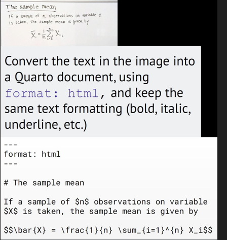

- Data entry
  - *Prompt: Convert the table in the image into a downloadable CSV.*
    - Shows you an interactive preview of the dataset; can also modify it on the fly (e.g., highlight different columns/cells, provide data cleaning/formatting instructions)
  - *Prompt: Simulate additional observations so that there are 1000 rows. Create two additional variables, “Years of Experience” and “Education level.” Ensure that the generated information and salaries are realistic.*
  - *Prompt: Provide a short overview of the dataset, including the data types for each variable.*
  - *Prompt: Provide summary statistics.*
  - *Prompt: Analyze the dataset and extract interesting facts. Use data storytelling techniques to weave together a short (75 word) paragraph that pulls together key insights.*
- Analysis
  - *Prompt: Create a data visualization using the salaries dataset. Put average salary on the y-axis and job role on the x-axis. Use a different color for each job role. Create a bar chart that’s faceted by the industry variable. Add a horizontal black line showing the average salary for each industry. Format the y-axis as dollar amounts. Use a modern color palette and a minimal theme. Display a legend on the right.*
    - Write prompt to be consistent with the grammar of graphics
    - Will show you code and graph (you can now run Python code directly within chat)
- Creating slides using Quarto themes
  - GitHub Pages / GitLab Pages to host a Quarto project
    - [Generative AI Quarto Theme Generator Shiny App](https://melissavanbussel.shinyapps.io/quarto_theme_generator/)
- Creating a logo for a hex sticker
  - Transparent background, scaled easily without becoming pixelated
  - Text to svg generators
    - Example: [Recraft AI](https://www.recraft.ai)
    - Text prompt and specify height, width, color palette, how simple/detailed, art styles
    - Generate mock-ups
- Two tools that use Generative AI to make teaching and communicating about data easier
  - [Scribe](https://scribehow.com/): Automatically create step-by-step tutorials without copy-pasting screenshots or recording videos
    - Scribe Chrome extension to create automatic screenshots/instructions (e.g., where you clicked will be highlighted)
    - Can share it for free (direct link or by email)
    - Can embed as an iframe, for example, on a Quarto website
    - Pro-subscription for desktop version of Scribe; can export in variety of formats (including Markdown)
  - [descript](https://www.descript.com): Edit videos and audio/podcasts as if you’re editing a Word document
    - Upload video/audio file and it will be transcribed (available in over 20 different language)
    - Once the transcript is ready, you can edit the transcript in order to edit the video itself
    - Can remove awkward silences (shorten word gaps) and remove filler words
    - AI speech generation capabilities
      - Regenerate: You can use your voice clone to regenerate content
      - Overdub: You can use to replace wordings
    - Other AI features
      - Eye contact
      - Remove retakes
      - YouTube descriptions: from your transcript, descript will generate a YouTube-style description and provide timestamps for sections
- Guidelines for responsible use
  - [Guide on the use of generative artificial intelligence of Canada](https://www.canada.ca/en/government/system/digital-government/digital-government-innovations/responsible-use-ai/guide-use-generative-ai.html)

## Day 2 (08/14/2024)

### A future of data science

```markdown
Wednesday, Aug 14 9:00 AM - 10:00 AM PDT
```

**Keynote Info**

- Presenter: Allen Downey
- [[Slides](https://docs.google.com/presentation/d/e/2PACX-1vSdoq58S1DbhSKikfu3m52B4oMB5DFgyvxr0qy4Rhilojq6G2oRqTLmWMKuKtEBQVoDEr-XXv0--10H/pub?slide=id.p)]
- Keynote speaker argues data science exists because statistics missed the boat on computers
  - Technological trigger for data science was computation because statistics as a field missed the boat on computation
- Hype of data science
  - Technology trigger
  - Peak of inflated expectations (2012)
  - Trough of disillusionment (2016-)
  - Slope of enlightenment
  - Plateau of productivity
- Slope of enlightenment
  - Two things that make me optimistic
    - Improving data literacy
    - More and more available data
  - One that makes me worry
    - Excessive consumption of relentless negative media

### Data Wrangling [for Python or R] Like a Boss With DuckDB

```markdown
Wednesday, Aug 14 4:15 PM - 5:15 PM PDT
```

**Keynote Info**

- Presenter: Hannes Mühleisen
- [`DuckDB` package](https://duckdb.org/docs/installation/)
  - Advanced CSV reader
  - Native support for Parquet files and Arrow structures
  - An efficient parallel vectorized query processing engine
  - Support for efficient atomic updates to tables
- Advantages
  - Zero-dependency package available in multiple languages
  - Batteries included: Fully featured data management system
  - Fast
  - Free!
- Simple queries
  - Read dataset (`CREATE TABLE ... AS FROM Data8277.csv`)
  - Compute summary statistics (`SUMMARIZE FROM "Data8277.csv`)
- [`duckplyr` R package](https://duckdb.org/2024/04/02/duckplyr.html): `dplyr` + `DuckDB`